# Power Validation

# Power Validation

Using the TrialSize package to calculate sample sizes base on examplesfrom Chow SC, Shao J, Wang H. Sample Size Calculation in Clinical Research. New York: Marcel Dekker, 2008.

```r
library(TrialSize)
library(TOSTER)

#Power for one-sample TOST based on raw scores
Example.3.1.4<-OneSampleMean.Equivalence(alpha=0.05,beta=0.2,sigma=0.1,delta=0.05,margin=0)
Example.3.1.4   # 35
```

```
## [1] 34.25539
```

```r
powerTOSTone.raw(alpha=0.05, statistical_power=0.8, sd = 0.1, low_eqbound=-0.05, high_eqbound=0.05, epsilon=0) #35
```

```
## The required sample size to achieve 80 % power with equivalence bounds of -0.05 and 0.05 is 35
```

```
## [1] 35
```

```r
#Power for two-sample independent t-test based on raw scores
Example.3.2.4<-TwoSampleMean.Equivalence(alpha=0.1,beta=0.1,sigma=0.1,k=1,delta=0.05,margin=0.01)
Example.3.2.4 #107 (but ceiling rounded 108)
```

```
## [1] 107.0481
```

```r
#Margin 0.01 is identical to using bounds - margin, so 0.04
powerTOSTtwo.raw(alpha=0.1, statistical_power=0.9, low_eqbound=-0.04, high_eqbound=0.04, sdpooled=0.1) #108
```

```
## The required sample size to achieve 90 % power with equivalence bounds of -0.04 and 0.04 is 108 per group, or 216 in total.
```

```
## [1] 108
```

Table 1 Julious (2004) provides the sample sizes for *superiority* tests for a independent-samples *t*-test standardized effect sizes from 0.05 to 1.5, based equal sample sizes (in column 1). We can use the powerTOSTtwo function to calculate these values. Compared to an equivalence test, we can use the powerTOSTtwo function, when we double the alpha, and halve the Type 2 error. For alpha = 0.5 and a statistical power of 0.9, this means we will fill in an alpha of 0.1 and a statistical power of 0.95.

Table 1: bound N 0.05 8407 0.10 2103 0.15 935 0.20 527 0.25 338 0.30 235 0.35 173 0.40 133 0.45 105 0.50 86 0.55 71 0.60 60 0.65 51 0.70 44 0.75 39 0.80 34 0.85 31 0.90 27 0.95 25 1.00 23 1.05 21 1.10 19 1.15 17 1.20 16 1.25 15 1.30 14 1.35 13 1.40 12 1.45 12 1.50 11

```r
require(TOSTER)

dlist<-seq(0.05,1.5,0.05)
samplesize<-numeric(length(dlist))
for(i in 1:length(dlist)){
  samplesize[i]<-powerTOSTtwo(alpha=0.1, statistical_power=0.95, low_eqbound_d=-(dlist[i]), high_eqbound_d=(dlist[i]))
}
```

```
## The required sample size to achieve 95 % power with equivalence bounds of -0.05 and 0.05 is 8406 per group, or 16812 in total.
```

```
## The required sample size to achieve 95 % power with equivalence bounds of -0.1 and 0.1 is 2102 per group, or 4204 in total.
```

```
## The required sample size to achieve 95 % power with equivalence bounds of -0.15 and 0.15 is 934 per group, or 1868 in total.
```

```
## The required sample size to achieve 95 % power with equivalence bounds of -0.2 and 0.2 is 526 per group, or 1052 in total.
```

```
## The required sample size to achieve 95 % power with equivalence bounds of -0.25 and 0.25 is 337 per group, or 674 in total.
```

```
## The required sample size to achieve 95 % power with equivalence bounds of -0.3 and 0.3 is 234 per group, or 468 in total.
```

```
## The required sample size to achieve 95 % power with equivalence bounds of -0.35 and 0.35 is 172 per group, or 344 in total.
```

```
## The required sample size to achieve 95 % power with equivalence bounds of -0.4 and 0.4 is 132 per group, or 264 in total.
```

```
## The required sample size to achieve 95 % power with equivalence bounds of -0.45 and 0.45 is 104 per group, or 208 in total.
```

```
## The required sample size to achieve 95 % power with equivalence bounds of -0.5 and 0.5 is 85 per group, or 170 in total.
```

```
## The required sample size to achieve 95 % power with equivalence bounds of -0.55 and 0.55 is 70 per group, or 140 in total.
```

```
## The required sample size to achieve 95 % power with equivalence bounds of -0.6 and 0.6 is 59 per group, or 118 in total.
```

```
## The required sample size to achieve 95 % power with equivalence bounds of -0.65 and 0.65 is 50 per group, or 100 in total.
```

```
## The required sample size to achieve 95 % power with equivalence bounds of -0.7 and 0.7 is 43 per group, or 86 in total.
```

```
## The required sample size to achieve 95 % power with equivalence bounds of -0.75 and 0.75 is 38 per group, or 76 in total.
```

```
## The required sample size to achieve 95 % power with equivalence bounds of -0.8 and 0.8 is 33 per group, or 66 in total.
```

```
## The required sample size to achieve 95 % power with equivalence bounds of -0.85 and 0.85 is 30 per group, or 60 in total.
```

```
## The required sample size to achieve 95 % power with equivalence bounds of -0.9 and 0.9 is 26 per group, or 52 in total.
```

```
## The required sample size to achieve 95 % power with equivalence bounds of -0.95 and 0.95 is 24 per group, or 48 in total.
```

```
## The required sample size to achieve 95 % power with equivalence bounds of -1 and 1 is 22 per group, or 44 in total.
```

```
## The required sample size to achieve 95 % power with equivalence bounds of -1.05 and 1.05 is 20 per group, or 40 in total.
```

```
## The required sample size to achieve 95 % power with equivalence bounds of -1.1 and 1.1 is 18 per group, or 36 in total.
```

```
## The required sample size to achieve 95 % power with equivalence bounds of -1.15 and 1.15 is 16 per group, or 32 in total.
```

```
## The required sample size to achieve 95 % power with equivalence bounds of -1.2 and 1.2 is 15 per group, or 30 in total.
```

```
## The required sample size to achieve 95 % power with equivalence bounds of -1.25 and 1.25 is 14 per group, or 28 in total.
```

```
## The required sample size to achieve 95 % power with equivalence bounds of -1.3 and 1.3 is 13 per group, or 26 in total.
```

```
## The required sample size to achieve 95 % power with equivalence bounds of -1.35 and 1.35 is 12 per group, or 24 in total.
```

```
## The required sample size to achieve 95 % power with equivalence bounds of -1.4 and 1.4 is 11 per group, or 22 in total.
```

```
## The required sample size to achieve 95 % power with equivalence bounds of -1.45 and 1.45 is 10 per group, or 20 in total.
```

```
## The required sample size to achieve 95 % power with equivalence bounds of -1.5 and 1.5 is 10 per group, or 20 in total.
```

```r
samplesize
```

```
##  [1] 8406 2102  934  526  337  234  172  132  104   85   70   59   50   43
## [15]   38   33   30   26   24   22   20   18   16   15   14   13   12   11
## [29]   10   10
```

Calculations differ only one or 2 participants max, due to the approximation that is used.

We can also recreate Table 3, column 1, which includes sample sizes for 90% power and alpha = 0.025, assuming equal sample sizes and a try effect size of 0.

```r
require(TOSTER)

dlist<-seq(0.05,1.5,0.05)
samplesize<-numeric(length(dlist))
for(i in 1:length(dlist)){
  samplesize[i]<-powerTOSTtwo(alpha=0.025, statistical_power=0.9, low_eqbound_d=-(dlist[i]), high_eqbound_d=(dlist[i]))
}
```

```
## The required sample size to achieve 90 % power with equivalence bounds of -0.05 and 0.05 is 10396 per group, or 20792 in total.
```

```
## The required sample size to achieve 90 % power with equivalence bounds of -0.1 and 0.1 is 2599 per group, or 5198 in total.
```

```
## The required sample size to achieve 90 % power with equivalence bounds of -0.15 and 0.15 is 1156 per group, or 2312 in total.
```

```
## The required sample size to achieve 90 % power with equivalence bounds of -0.2 and 0.2 is 650 per group, or 1300 in total.
```

```
## The required sample size to achieve 90 % power with equivalence bounds of -0.25 and 0.25 is 416 per group, or 832 in total.
```

```
## The required sample size to achieve 90 % power with equivalence bounds of -0.3 and 0.3 is 289 per group, or 578 in total.
```

```
## The required sample size to achieve 90 % power with equivalence bounds of -0.35 and 0.35 is 213 per group, or 426 in total.
```

```
## The required sample size to achieve 90 % power with equivalence bounds of -0.4 and 0.4 is 163 per group, or 326 in total.
```

```
## The required sample size to achieve 90 % power with equivalence bounds of -0.45 and 0.45 is 129 per group, or 258 in total.
```

```
## The required sample size to achieve 90 % power with equivalence bounds of -0.5 and 0.5 is 104 per group, or 208 in total.
```

```
## The required sample size to achieve 90 % power with equivalence bounds of -0.55 and 0.55 is 86 per group, or 172 in total.
```

```
## The required sample size to achieve 90 % power with equivalence bounds of -0.6 and 0.6 is 73 per group, or 146 in total.
```

```
## The required sample size to achieve 90 % power with equivalence bounds of -0.65 and 0.65 is 62 per group, or 124 in total.
```

```
## The required sample size to achieve 90 % power with equivalence bounds of -0.7 and 0.7 is 54 per group, or 108 in total.
```

```
## The required sample size to achieve 90 % power with equivalence bounds of -0.75 and 0.75 is 47 per group, or 94 in total.
```

```
## The required sample size to achieve 90 % power with equivalence bounds of -0.8 and 0.8 is 41 per group, or 82 in total.
```

```
## The required sample size to achieve 90 % power with equivalence bounds of -0.85 and 0.85 is 36 per group, or 72 in total.
```

```
## The required sample size to achieve 90 % power with equivalence bounds of -0.9 and 0.9 is 33 per group, or 66 in total.
```

```
## The required sample size to achieve 90 % power with equivalence bounds of -0.95 and 0.95 is 29 per group, or 58 in total.
```

```
## The required sample size to achieve 90 % power with equivalence bounds of -1 and 1 is 26 per group, or 52 in total.
```

```
## The required sample size to achieve 90 % power with equivalence bounds of -1.05 and 1.05 is 24 per group, or 48 in total.
```

```
## The required sample size to achieve 90 % power with equivalence bounds of -1.1 and 1.1 is 22 per group, or 44 in total.
```

```
## The required sample size to achieve 90 % power with equivalence bounds of -1.15 and 1.15 is 20 per group, or 40 in total.
```

```
## The required sample size to achieve 90 % power with equivalence bounds of -1.2 and 1.2 is 19 per group, or 38 in total.
```

```
## The required sample size to achieve 90 % power with equivalence bounds of -1.25 and 1.25 is 17 per group, or 34 in total.
```

```
## The required sample size to achieve 90 % power with equivalence bounds of -1.3 and 1.3 is 16 per group, or 32 in total.
```

```
## The required sample size to achieve 90 % power with equivalence bounds of -1.35 and 1.35 is 15 per group, or 30 in total.
```

```
## The required sample size to achieve 90 % power with equivalence bounds of -1.4 and 1.4 is 14 per group, or 28 in total.
```

```
## The required sample size to achieve 90 % power with equivalence bounds of -1.45 and 1.45 is 13 per group, or 26 in total.
```

```
## The required sample size to achieve 90 % power with equivalence bounds of -1.5 and 1.5 is 12 per group, or 24 in total.
```

```r
samplesize
```

```
##  [1] 10396  2599  1156   650   416   289   213   163   129   104    86
## [12]    73    62    54    47    41    36    33    29    26    24    22
## [23]    20    19    17    16    15    14    13    12
```

We again see a difference in sample size of 1 at most due to the approximation using here.

# Validation through simulation

We can calculate the sample size needed to achieve 80% power in a paired samples equivalence test:

```r
require(TOSTER)
powerTOSTpaired(alpha=0.05, statistical_power=0.8, low_eqbound_dz=-0.1, high_eqbound_dz=0.1, epsilon=0) #Calculate n pairs
```

```
## The required sample size to achieve 80 % power with equivalence bounds of -0.1 and 0.1 is 857 pairs
```

```
## [1] 857
```

```r
#Required N: 857 pairs
```

Subsequently, we can simulate paired samples TOST tests with given sample size, which gives 80% power.

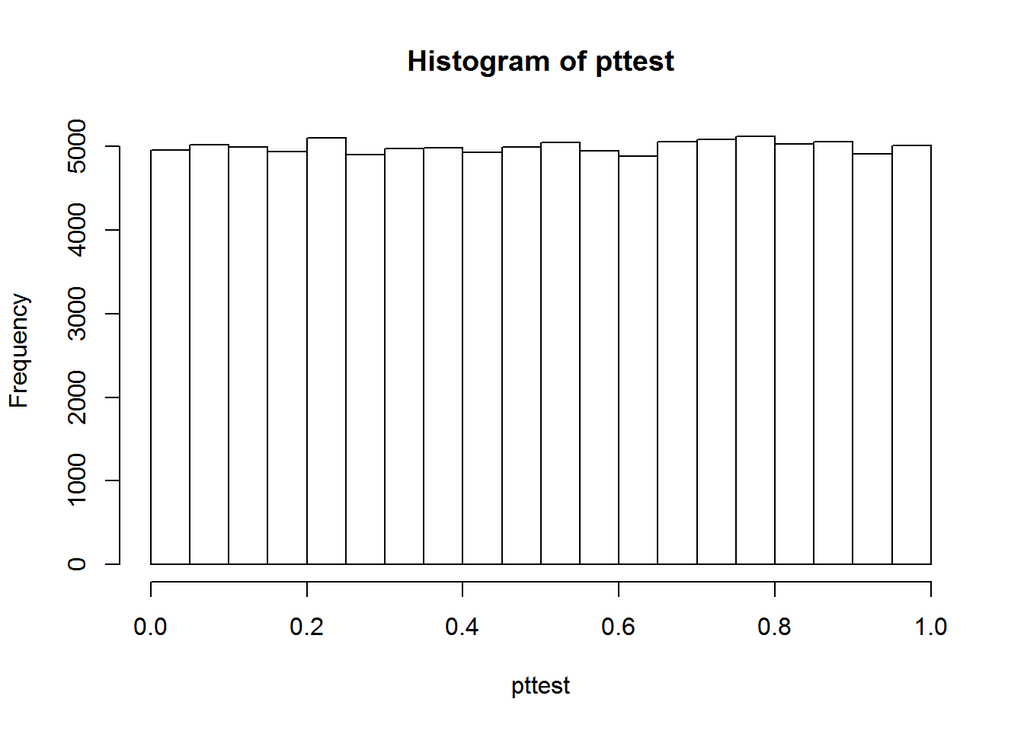

```r
library(mvtnorm) #to simulate correlated data
n <- 857 #set sample size simulation based on pwer
r <- 0.0 #set correlation
low_eqbound_dz=-0.1
high_eqbound_dz=0.1
sd<-4
alpha<-0.05
nSims <- 100000 #number of simulated experiments
pttest<-numeric(nSims) #set up empty container for all simulated p-values
ptost<-numeric(nSims) #set up empty container for all simulated p-values

for(i in 1:nSims){ #for each simulated experiment
  a <- rmvnorm(n=n,mean=c(0.0,0.0),sigma=matrix(c(sd,r,r,sd), 2,2))
  x<-a[,1]
  y<-a[,2]
  m1<-mean(x)
  m2<-mean(y)
  sd1<-sd(x)
  sd2<-sd(y)
  r12<-cor(x,y)
  sdif<-sqrt(sd1^2+sd2^2-2*r12*sd1*sd2)
  se<-sdif/sqrt(n)
  low_eqbound<-low_eqbound_dz*sdif
  high_eqbound<-high_eqbound_dz*sdif
  t<-(m1-m2)/se
  degree_f<-n-1
  pttest[i]<-2*pt(abs(t), degree_f, lower=FALSE)
  t1<-((m1-m2)+(low_eqbound))/se
  p1<-1-pt(t1, degree_f, lower=FALSE)
  t2<-((m1-m2)+(high_eqbound))/se
  p2<-pt(t2, degree_f, lower=FALSE)
  ttost<-ifelse(abs(t1) < abs(t2), t1, t2)
  LL90<-((m1-m2)-qt(1-alpha, degree_f)*se)
  UL90<-((m1-m2)+qt(1-alpha, degree_f)*se)
  ptost[i]<-max(p1,p2)
}

#P-value distribution normal t-test (uniform because null is true)
hist(pttest, breaks=20, xlim=c(0,1))
```

```r
sum(pttest<0.05) #Type 1 error rate for NHST
```

```
## [1] 4960
```

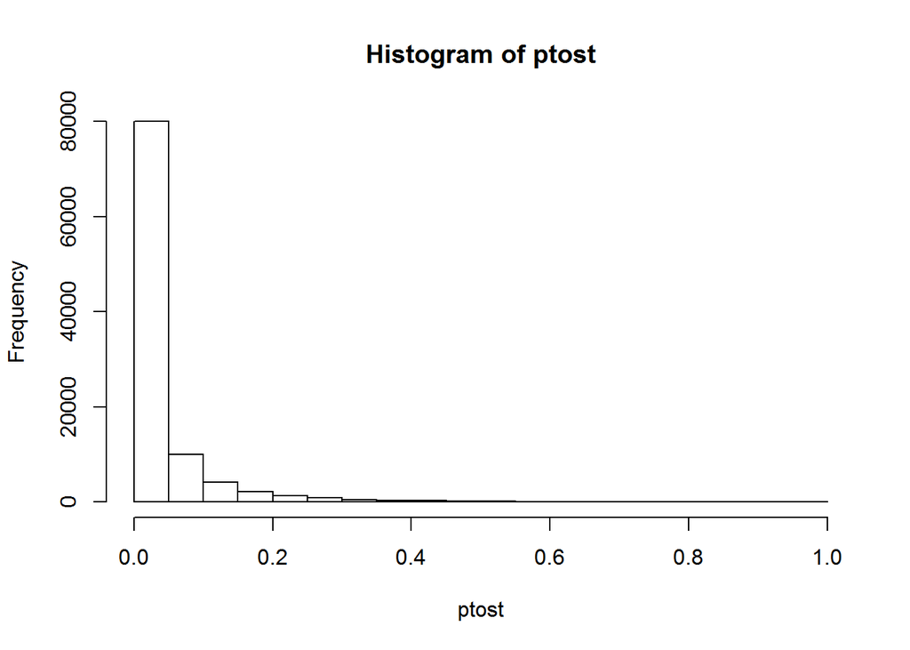

```r
#P-value distribution TOST
hist(ptost, breaks=20, xlim=c(0,1))
```

```r
sum(ptost<0.05) #Power for TOST
```

```
## [1] 80008
```